# Dataset Exploration of Prosper Loan Dataset

## by Akoh John Ojoarome

1. Introduction
2. Prelim-Wrangling
   - Data Assessment
   - Assessment Summary
   - Data Cleaning
3. EDA
   - Univariate Exploration
   - Bivariate Exploration
   - Multivariate Exploration
4. Conclusions
5. Limitations
6. References

## Introduction

Prosper was founded in 2005 as the first peer-to-peer lending marketplace in the United States. Since then, Prosper has facilitated more than 22 billion in loans to more than 1,330,000 people.

Through Prosper, people can invest in each other in a way that is financially and socially rewarding. Borrowers apply online for a fixed-rate, fixed-term loan between 2,000USD and 40,000USD. Individuals and institutions can invest in the loans and earn attractive returns. Prosper handles all loan servicing on behalf of the matched borrowers and investors.

This data set contains 113,937 loans with 81 variables on each loan, including loan amount, borrower rate (or interest rate), current loan status, borrower income, and many others. We will be exploring a sample of this dataset with more emphasis on Cost of Capital, LoanStatus.

```python
# import all packages necessary for analysis and Visualisation
import numpy as np
import pandas as pd
import matplotlib.pyplot as plt
import seaborn as sb
import warnings
warnings.filterwarnings('ignore')

%matplotlib inline
```

# Preliminary Wrangling

We Commence Wrangling Operations by first setting up working environmnets and loading the dataset

```python
# Display all rows, columns and cells
pd.set_option('display.max_rows', None, 'display.max_columns', None, 'display.max_colwidth', None)
```

```python
# Read table into pandas dataframe
data = pd.read_csv('prosperLoanData.csv')
```

```python
# high-level overview of data shape and composition
print(data.shape)
print(data.info())
```

```
(113937, 81)
<class 'pandas.core.frame.DataFrame'>
RangeIndex: 113937 entries, 0 to 113936
Data columns (total 81 columns):
 #   Column                               Non-Null Count   Dtype
---  ------                               --------------   -----
 0   ListingKey                           113937 non-null  object
 1   ListingNumber                        113937 non-null  int64
 2   ListingCreationDate                  113937 non-null  object
 3   CreditGrade                          28953 non-null   object
 4   Term                                 113937 non-null  int64
 5   LoanStatus                           113937 non-null  object
 6   ClosedDate                           55089 non-null   object
 7   BorrowerAPR                          113912 non-null  float64
 8   BorrowerRate                         113937 non-null  float64
```

[output cut: 75 more lines]

### What is the structure of your dataset?

> The structure of the dataset is 113,937 rows, 81 columns containing data about the loans from quarter four in 2005 to quarter one in 2014

### What is/are the main feature(s) of interest in your dataset?

> I am interested in finding uncovering interactions among (Borrower APR) and explanatory variables, and how BorrowerAPR might interact with LoanStatus and Credit worthiness.

### What features in the dataset do you think will help support your investigation into your feature(s) of interest?:

Few variables that will be anlayzed here include,

**BorrowerAPR**: The Borrower’s APR for the loan. Every borrower is concerned about the APR, he/she will be charged for the loan, hence it is crucial to study it. **ProsperRating**: The Prosper Rating assigned at the time the listing was created, between AA - HR. The rating assigned by Prosper helps to decide the APR the borrower should be charged. **CreditScoreRnge**: The lower value representing the range of the borrower's credit score as provided by a consumer credit rating agency. **Bank Card Utilization** : The percentage of available revolving credit that is utilized at the time the credit profile was pulled. Higher balance on the credit card indicates borrower’s inability to pay off debts. **EstimatedLoss** : Estimated loss is the estimated principal loss on charge-offs. Applicable for loans originated after July 2009. Borrowers are often cautious in investing money in ventures with high loss, hence estimated loss is crucial. **DebtToIncomeRatio** : The debt to income ratio of the borrower at the time the credit profile was pulled. This value is Null if the debt to income ratio is not available. This value is capped at 10.01. The ratio of debt to income indicates spending habits of the borrower. **LoanOriginalAmount** : The origination amount of the loan. **IncomeRange** : The income range of the borrower at the time the listing was created. It is highly probable that high earning borrowers will be granted higher loan amount. **StatedMonthlyIncome** : The monthly income the borrower stated at the time the listing was created. Similar to IncomeRange, monthly income gives information about the credibility of the borrower. **LoanStatus**: The current status of the loan: Cancelled, Chargedoff, Completed, Current, Defaulted, FinalPaymentInProgress, PastDue. The PastDue status will be accompanied by a delinquency bucket. This variable needs to be investigated to determine loan performance at state level.

## Data Wrangling: Assessment & Cleaning

```python
# After careful consideration, the more important variables for our analysis has been selected
interested = np.r_[0, 4, 5, 7, 11, 14, 15, 16, 17, 19, 20, 25, 26, 35, 41, 42, 46, 47, 49, 63]
loanDf = data.iloc[:, interested]
```

```python
# Now we assess the first 5 rows of our selected variables
print(loanDf.shape)
print(loanDf.info())
loanDf.head()
```

```
(113937, 20)
<class 'pandas.core.frame.DataFrame'>
RangeIndex: 113937 entries, 0 to 113936
Data columns (total 20 columns):
 #   Column                     Non-Null Count   Dtype
---  ------                     --------------   -----
 0   ListingKey                 113937 non-null  object
 1   Term                       113937 non-null  int64
 2   LoanStatus                 113937 non-null  object
 3   BorrowerAPR                113912 non-null  float64
 4   EstimatedLoss              84853 non-null   float64
 5   ProsperRating (Alpha)      84853 non-null   object
 6   ProsperScore               84853 non-null   float64
 7   ListingCategory (numeric)  113937 non-null  int64
 8   BorrowerState              108422 non-null  object
 9   EmploymentStatus           111682 non-null  object
 10  EmploymentStatusDuration   106312 non-null  float64
 11  CreditScoreRangeLower      113346 non-null  float64
 12  CreditScoreRangeUpper      113346 non-null  float64
 13  CurrentDelinquencies       113240 non-null  float64
 14  BankcardUtilization        106333 non-null  float64
 15  AvailableBankcardCredit    106393 non-null  float64
 16  DebtToIncomeRatio          105383 non-null  float64
 17  IncomeRange                113937 non-null  object
 18  StatedMonthlyIncome        113937 non-null  float64
 19  LoanOriginalAmount         113937 non-null  int64
dtypes: float64(11), int64(3), object(6)
memory usage: 17.4+ MB
None
```

|  | ListingKey | Term | LoanStatus | BorrowerAPR | EstimatedLoss | ProsperRating (Alpha) | ProsperScore | ListingCategory (numeric) | BorrowerState | EmploymentStatus | EmploymentStatusDuration | CreditScoreRangeLower | CreditScoreRangeUpper | CurrentDelinquencies | BankcardUtilization | AvailableBankcardCredit | DebtToIncomeRatio | IncomeRange | StatedMonthlyIncome | LoanOriginalAmount |
| --- | --- | --- | --- | --- | --- | --- | --- | --- | --- | --- | --- | --- | --- | --- | --- | --- | --- | --- | --- | --- |
| 0 | 1021339766868145413AB3B | 36 | Completed | 0.16516 | NaN | NaN | NaN | 0 | CO | Self-employed | 2.0 | 640.0 | 659.0 | 2.0 | 0.00 | 1500.0 | 0.17 | $25,000-49,999 | 3083.333333 | 9425 |
| 1 | 10273602499503308B223C1 | 36 | Current | 0.12016 | 0.0249 | A | 7.0 | 2 | CO | Employed | 44.0 | 680.0 | 699.0 | 0.0 | 0.21 | 10266.0 | 0.18 | $50,000-74,999 | 6125.000000 | 10000 |
| 2 | 0EE9337825851032864889A | 36 | Completed | 0.28269 | NaN | NaN | NaN | 0 | GA | Not available | NaN | 480.0 | 499.0 | 1.0 | NaN | NaN | 0.06 | Not displayed | 2083.333333 | 3001 |
| 3 | 0EF5356002482715299901A | 36 | Current | 0.12528 | 0.0249 | A | 9.0 | 16 | GA | Employed | 113.0 | 800.0 | 819.0 | 4.0 | 0.04 | 30754.0 | 0.15 | $25,000-49,999 | 2875.000000 | 10000 |
| 4 | 0F023589499656230C5E3E2 | 36 | Current | 0.24614 | 0.0925 | D | 4.0 | 2 | MN | Employed | 44.0 | 680.0 | 699.0 | 0.0 | 0.81 | 695.0 | 0.26 | $100,000+ | 9583.333333 | 15000 |

## Assessment Summary

After Visual and Programmatic Assessment, the following has been identified:

ListingCategory (numeric) and ProsperRating (Alpha) should be relabeled for better reference. ListingCategory (numeric) should be reassigned explanatory values as shown in the data dictionary. Not employed entries in IncomeRange could be safely replaced with $0. Key features for loan favorability (BorrowerAPR and ProsperRating (Alpha)) contain null values. The DebtToIncomeRatio column also contains null values. ProsperRating and IncomeRange are ordinal categorical variables and should be stored in ordered form.

## Data Cleaning

```python
# To begin the cleaning process, we make a copy of the dataframe for reference
loanClean = loanDf.copy()
```

```python
# Overview of the Dataframe
loanClean.info()
```

```
<class 'pandas.core.frame.DataFrame'>
RangeIndex: 113937 entries, 0 to 113936
Data columns (total 20 columns):
 #   Column                     Non-Null Count   Dtype
---  ------                     --------------   -----
 0   ListingKey                 113937 non-null  object
 1   Term                       113937 non-null  int64
 2   LoanStatus                 113937 non-null  object
 3   BorrowerAPR                113912 non-null  float64
 4   EstimatedLoss              84853 non-null   float64
 5   ProsperRating (Alpha)      84853 non-null   object
 6   ProsperScore               84853 non-null   float64
 7   ListingCategory (numeric)  113937 non-null  int64
 8   BorrowerState              108422 non-null  object
 9   EmploymentStatus           111682 non-null  object
 10  EmploymentStatusDuration   106312 non-null  float64
 11  CreditScoreRangeLower      113346 non-null  float64
 12  CreditScoreRangeUpper      113346 non-null  float64
 13  CurrentDelinquencies       113240 non-null  float64
 14  BankcardUtilization        106333 non-null  float64
 15  AvailableBankcardCredit    106393 non-null  float64
 16  DebtToIncomeRatio          105383 non-null  float64
 17  IncomeRange                113937 non-null  object
 18  StatedMonthlyIncome        113937 non-null  float64
 19  LoanOriginalAmount         113937 non-null  int64
dtypes: float64(11), int64(3), object(6)
memory usage: 17.4+ MB
```

```python
# Define: Check for duplicate rows, there are zero duplicate rows
#Code & Test
loanClean.duplicated().sum()
```

```
0
```

```python
# Check for null values, there seems to be alot of null values in 12 columns
loanClean.isnull().sum()
```

```
ListingKey                       0
Term                             0
LoanStatus                       0
BorrowerAPR                     25
EstimatedLoss                29084
ProsperRating (Alpha)        29084
ProsperScore                 29084
ListingCategory (numeric)        0
BorrowerState                 5515
EmploymentStatus              2255
EmploymentStatusDuration      7625
CreditScoreRangeLower          591
CreditScoreRangeUpper          591
CurrentDelinquencies           697
BankcardUtilization           7604
AvailableBankcardCredit       7544
DebtToIncomeRatio             8554
IncomeRange                      0
StatedMonthlyIncome              0
LoanOriginalAmount               0
dtype: int64
```

```python
# Considering that ProsperRating is integral to the analysis, I will be subsetting the dataframe
loanClean = loanClean.loc[loanClean['ProsperRating (Alpha)'].notnull()]
```

```python
# Upon re-examination of the dataframe, most null entries have been eliminated
loanClean.isnull().sum()
```

```
ListingKey                      0
Term                            0
LoanStatus                      0
BorrowerAPR                     0
EstimatedLoss                   0
ProsperRating (Alpha)           0
ProsperScore                    0
ListingCategory (numeric)       0
BorrowerState                   0
EmploymentStatus                0
EmploymentStatusDuration       19
CreditScoreRangeLower           0
CreditScoreRangeUpper           0
CurrentDelinquencies            0
BankcardUtilization             0
AvailableBankcardCredit         0
DebtToIncomeRatio            7296
IncomeRange                     0
StatedMonthlyIncome             0
LoanOriginalAmount              0
dtype: int64
```

```python
# Define: Fill Null values in DebtToIncomeRatio column with it's mean.

# Code:
loanClean.DebtToIncomeRatio.fillna(loanClean.DebtToIncomeRatio.mean(), inplace=True)

# Test:
loanClean.DebtToIncomeRatio.isnull().sum()
```

```
0
```

```python
# Define: Make Terms variable an ordinal categorical variable

# Code:
terms = loanClean.Term.unique().tolist().sort()
Lterms = pd.api.types.CategoricalDtype(ordered=True, categories=terms)
loanClean.Term = loanClean.Term.astype(Lterms)

# Test:
loanClean.Term.dtype
```

```
CategoricalDtype(categories=[12, 36, 60], ordered=True)
```

```python
# Define: Make LoanStatus Variable a categorical data type

# Code:
loanClean.LoanStatus = loanClean.LoanStatus.astype('category')

# Test:
loanClean.LoanStatus.dtypes
```

```
CategoricalDtype(categories=['Chargedoff', 'Completed', 'Current', 'Defaulted',
                  'FinalPaymentInProgress', 'Past Due (1-15 days)',
                  'Past Due (16-30 days)', 'Past Due (31-60 days)',
                  'Past Due (61-90 days)', 'Past Due (91-120 days)',
                  'Past Due (>120 days)'],
, ordered=False)
```

```python
# Define: Relabel column names

# Code:
loanClean.rename(columns={'ListingCategory (numeric)':'ListingCategory', 'ProsperRating (Alpha)':'ProsperRating'}, inplace=True )

# Test:
reLabel = ['ListingCategory', 'ProsperRating']

for col in reLabel:
    if col in loanClean.columns:
        print(col)
```

```
ListingCategory
ProsperRating
```

```python
loanClean.ListingCategory.unique()
```

```
array([ 2, 16,  1,  7, 13,  6, 15, 20, 19, 18,  3,  8, 11, 14,  9, 17, 10,
        0,  5, 12], dtype=int64)
```

```python
# Define: Remap values in Listing Category and Change data type

# Code:
loanClean.ListingCategory.replace({0 : 'Not Available', 1 : 'Debt Consolidation', 2 : 'Home Improvement', 3: 'Business',
                   5 : 'Student Use', 6 : 'Auto', 7 : 'Other', 8 : 'Baby & Adoption',
                   9 : 'Boat', 10 : 'Cosmetic Procedure', 11 : 'Engagement Ring', 12 : 'Green Loans',
                  13 : 'Household Expenses', 14 : 'Large Purchases', 15 : 'Medical or Dental', 16 : 'Motorcycle',
                  17 : 'RV', 18 : 'Taxes', 19 : 'Vacation', 20 : 'Wedding Loans'}, inplace=True)

loanClean['ListingCategory'] = loanClean['ListingCategory'].astype('category')

# Test:
loanClean.ListingCategory.dtypes
```

```
CategoricalDtype(categories=['Auto', 'Baby & Adoption', 'Boat', 'Business',
                  'Cosmetic Procedure', 'Debt Consolidation',
                  'Engagement Ring', 'Green Loans', 'Home Improvement',
                  'Household Expenses', 'Large Purchases', 'Medical or Dental',
                  'Motorcycle', 'Not Available', 'Other', 'RV', 'Student Use',
                  'Taxes', 'Vacation', 'Wedding Loans'],
, ordered=False)
```

```python
# Define: Make BorrowerState variable a Category Data type

# Code:
loanClean['BorrowerState'] = loanClean['BorrowerState'].astype('category')

# Test:
loanClean.BorrowerState.dtypes
```

```
CategoricalDtype(categories=['AK', 'AL', 'AR', 'AZ', 'CA', 'CO', 'CT', 'DC', 'DE', 'FL',
                  'GA', 'HI', 'ID', 'IL', 'IN', 'KS', 'KY', 'LA', 'MA', 'MD',
                  'MI', 'MN', 'MO', 'MS', 'MT', 'NC', 'NE', 'NH', 'NJ', 'NM',
                  'NV', 'NY', 'OH', 'OK', 'OR', 'PA', 'RI', 'SC', 'SD', 'TN',
                  'TX', 'UT', 'VA', 'VT', 'WA', 'WI', 'WV', 'WY'],
, ordered=False)
```

```python
# Define: Make Employment Status categorical data type
# Code:
loanClean['EmploymentStatus'] = loanClean['EmploymentStatus'].astype('category')
# Test:
loanClean.EmploymentStatus.dtype
```

```
CategoricalDtype(categories=['Employed', 'Full-time', 'Not employed', 'Other',
                  'Part-time', 'Retired', 'Self-employed'],
, ordered=False)
```

```python
# Define: Fill null entries in EmploymentStatusDuration column with its mean
# Code:
loanClean.EmploymentStatusDuration.fillna(loanClean.EmploymentStatusDuration.mean(), inplace=True)
```

```python
# Define: Change Column data types
# Code & Test
int_cols = ['EmploymentStatusDuration', 'CurrentDelinquencies', 'AvailableBankcardCredit', 'CreditScoreRangeLower', 'CreditScoreRangeUpper']

for col in int_cols:
    loanClean[col] = loanClean[col].astype(dtype='int')
    print(col, loanClean[col].dtypes)
```

```
EmploymentStatusDuration int32
CurrentDelinquencies int32
AvailableBankcardCredit int32
CreditScoreRangeLower int32
CreditScoreRangeUpper int32
```

```python
# Define: Contactenate CreditScoreRange columns and Change Data type to Categorical variable
# Code:
credit_range = ['CreditScoreRangeLower', 'CreditScoreRangeUpper']

for col in credit_range:
    loanClean[col] = loanClean[col].astype(dtype='str')

loanClean['CreditScoreRange'] = loanClean[credit_range].apply(lambda x: '-'.join(x), axis=1)

creditscore = loanClean['CreditScoreRange'].unique().tolist().sort()
creditrange = pd.api.types.CategoricalDtype(ordered=True, categories=creditscore)
loanClean['CreditScoreRange'] = loanClean['CreditScoreRange'].astype(creditrange)
# Test:
loanClean.CreditScoreRange.dtypes
```

```
CategoricalDtype(categories=['600-619', '620-639', '640-659', '660-679', '680-699',
                  '700-719', '720-739', '740-759', '760-779', '780-799',
                  '800-819', '820-839', '840-859', '860-879', '880-899'],
, ordered=True)
```

```python
# Define: Drop CreditScoreRangeUpper & CreditScoreRangeLower columns
# Code:
loanClean.drop(['CreditScoreRangeUpper', 'CreditScoreRangeLower'], axis=1, inplace=True)
# Test:
for col in credit_range:
    if col in loanClean:
        print(col)
    else:
        print('colum not found')
```

```
colum not found
colum not found
```

```python
# Define: Replace inconsistent value in IncomeRange column with consistent data
# Code:
loanClean.IncomeRange.replace('Not employed', '$0', inplace=True)

# Test:
loanClean.IncomeRange.unique()
```

```
array(['$50,000-74,999', '$25,000-49,999', '$100,000+', '$75,000-99,999',
       '$1-24,999', '$0'], dtype=object)
```

```python
# Define: Round up values for consistency
# Code:
loanClean['StatedMonthlyIncome'] = np.round(loanClean['StatedMonthlyIncome'], decimals=2)
# Test:
loanClean.StatedMonthlyIncome.unique()
```

```
array([ 6125.  ,  2875.  ,  9583.33, ...,  3430.58,  1539.17, 18756.  ])
```

```python
# Define: Change Column Data type for ProsperRating and IncomeRange Columns
# Code & Test
ordinal_var_dict = {'ProsperRating': ['HR', 'E', 'D', 'C', 'B', 'A', 'AA'],
                    'IncomeRange': ['$0', '$1-24,999', '$25,000-49,999',
                              '$50,000-74,999', '$75,000-99,999', '$100,000+']}

for var in ordinal_var_dict:
    ordered_var = pd.api.types.CategoricalDtype(ordered = True, categories = ordinal_var_dict[var])
    loanClean[var] = loanClean[var].astype(ordered_var)

loanClean[ordinal_var_dict.keys()].dtypes
```

```
ProsperRating    category
IncomeRange      category
dtype: object
```

```python
# Expand the width of Jupyter Notebook Cells
from IPython.core.display import display, HTML
display(HTML("<style>.container { width:100% !important; }</style>"))
```

```python
# Save a copy of Cleaned Prosper Loan Dataset
loanClean.to_csv('cleanloan.csv', index=False)
```

```python
loanClean.reset_index(drop=True, inplace=True)
```

# Exploratory Data Analysis

For a structured analysis we will be plotting univariate, bivariate and multivariate visualisations using the Question-Visualisation-Observation framework.

Extracting descriptive statistics on the numeric variables will be helpful in plotting histograms for visualisation distributions.

```python
# Display summary statistics for numeric columns
loanClean.describe()
```

|  | BorrowerAPR | EstimatedLoss | ProsperScore | EmploymentStatusDuration | CurrentDelinquencies | BankcardUtilization | AvailableBankcardCredit | DebtToIncomeRatio | StatedMonthlyIncome | LoanOriginalAmount |
| --- | --- | --- | --- | --- | --- | --- | --- | --- | --- | --- |
| count | 84853.000000 | 84853.000000 | 84853.000000 | 84853.000000 | 84853.000000 | 84853.000000 | 84853.000000 | 84853.000000 | 8.485300e+04 | 84853.000000 |
| mean | 0.226658 | 0.080306 | 5.950067 | 103.055307 | 0.322452 | 0.564219 | 11400.695355 | 0.258752 | 5.931175e+03 | 9083.440515 |
| std | 0.079916 | 0.046764 | 2.376501 | 97.068014 | 1.111996 | 0.301713 | 18610.424333 | 0.304333 | 8.239944e+03 | 6287.860058 |
| min | 0.045830 | 0.004900 | 1.000000 | 0.000000 | 0.000000 | 0.000000 | 0.000000 | 0.000000 | 0.000000e+00 | 1000.000000 |
| 25% | 0.163280 | 0.042400 | 4.000000 | 30.000000 | 0.000000 | 0.330000 | 1148.000000 | 0.160000 | 3.434000e+03 | 4000.000000 |
| 50% | 0.219450 | 0.072400 | 6.000000 | 74.000000 | 0.000000 | 0.600000 | 4574.000000 | 0.240000 | 5.000000e+03 | 7500.000000 |
| 75% | 0.292540 | 0.112000 | 8.000000 | 148.000000 | 0.000000 | 0.830000 | 13910.000000 | 0.310000 | 7.083330e+03 | 13500.000000 |
| max | 0.423950 | 0.366000 | 11.000000 | 755.000000 | 51.000000 | 2.500000 | 498374.000000 | 10.010000 | 1.750003e+06 | 35000.000000 |

## Univariate Exploration

In this section, I will be examining the distributions of the most relevant individual variables.

### Question: How is BorrowerAPR and ProsperRating distributed?

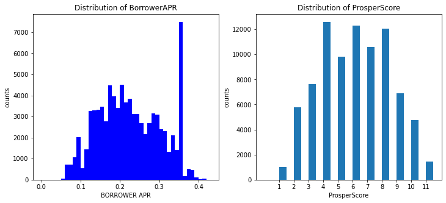

```python
plt.figure(figsize = [12, 5])

# Create bin sizes
bins = np.arange(0, loanClean.BorrowerAPR.max()+0.01, 0.01)
# Plot distribution of BorrowerAPR
plt.subplot(1,2,1)
plt.hist(data=loanClean, x='BorrowerAPR', bins=bins, color='b')
plt.xlabel('BORROWER APR')
plt.ylabel('counts')
plt.title("Distribution of BorrowerAPR");

# Plot distribution of Prosper Score
plt.subplot(1,2,2)
pbins = 1*np.arange(0, loanClean.ProsperScore.max()+1, 0.5) # Create bin sizes
plt.hist(data=loanClean, x='ProsperScore', bins=pbins)
plt.xlabel('ProsperScore')
plt.ylabel('counts')
plt.xticks(ticks=[1,2,3,4,5,6,7,8,9,10,11])
plt.title("Distribution of ProsperScore");
```

### Question: How is DebtToIncomeRatio distributed?

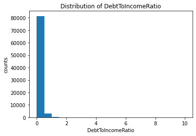

```python
# Plot DebttoincomeRatio
plt.hist(data=loanClean, x='DebtToIncomeRatio', bins=20);
plt.xlabel('DebtToIncomeRatio')
plt.ylabel('counts')
plt.title("Distribution of DebtToIncomeRatio");
```

**Observation**: From the above plot, we can observe that the bulk of the DebttoincomeRatio values are located between 0 and 2. Inorder to have a more clear picture of the distribution we can have to narrow our scope.

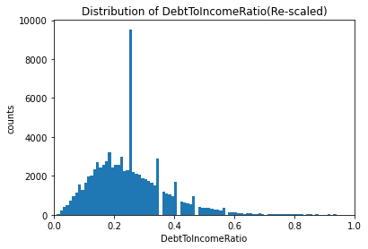

```python
# Examine the distribution more closely
dbins = np.arange(0, loanClean.DebtToIncomeRatio.max()+0.01, 0.01) #Create evenly spaced bins
plt.hist(data=loanClean, x='DebtToIncomeRatio', bins=dbins)
plt.xlabel('DebtToIncomeRatio')
plt.xlim(xmin=0,xmax=1)
plt.ylabel('counts')
plt.title("Distribution of DebtToIncomeRatio(Re-scaled)");
```

**Observation**: With the mean is greater than median, this indicates a relatively right skewed distribution, as shown by the histogram. There are a few peaks around 0.2 and 0.4, with 0.25 having the highest peak.

### Question: What is the distribution of EstimatedLoss and BankcardUtilization?

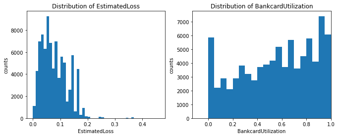

```python
# Plot the distribution of EstimatedLoss and Bankcardutilisation
plt.figure(figsize=[11,4])

plt.subplot(1,2,1) # Plot the distribution of EstimatedLoss
ebins = np.arange(0,loanClean.EstimatedLoss.max()+0.1, 0.01) # Create evenly spaced bins
plt.hist(data=loanClean, x='EstimatedLoss', bins=ebins)
plt.xlabel('EstimatedLoss')
plt.ylabel('counts')
plt.title("Distribution of EstimatedLoss");

plt.subplot(1,2,2) # Plot the distribution of Bankcardutilisation
bbins = np.arange(0,loanClean.BankcardUtilization.max()+0.1, 0.05)
plt.hist(data=loanClean, x='BankcardUtilization', bins=bbins)
plt.xlabel('BankcardUtilization')
plt.xlim(xmax=1)
plt.ylabel('counts')
plt.title("Distribution of BankcardUtilization");
```

We observe an interesting trend from the above histogram. The distribution of **Banlcardutlization** is relatively left skewed, Being left skewed makes sense, because most of the borrowers might have almost maxed out their credit limits. As seen from the summary stats, 75 percent of the population have used almost 84 percent of their limit. **EstimatedLoss**: We can observe that the distribution is rightly skewed, with most listing generating anticipated loss of 5%.

### Question: What is the distribution of StatedMonthlyIncome and LoanOriginalAmount?

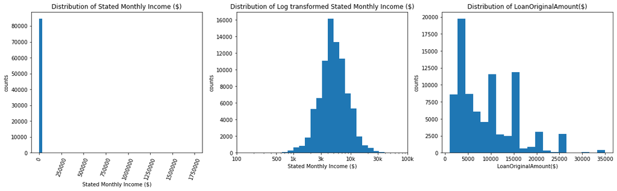

```python
plt.figure(figsize=[20,5])


plt.subplot(1, 3, 1) # Plot a standard distribution of the StatedMonthlyIncome distribution
plt.ticklabel_format(style='plain')
plt.hist(data=loanClean, x='StatedMonthlyIncome', bins=50)
plt.xlabel('Stated Monthly Income ($)')
plt.ylabel('counts')
plt.xticks(rotation=70)
plt.title("Distribution of Stated Monthly Income ($)");

plt.subplot(1,3,2) # Plot a transformed version of the StatedMonthlyIncome distribution
sbins = 10**np.arange(0,6.24+0.1, 0.1)
plt.hist(data=loanClean, x='StatedMonthlyIncome', bins=sbins)
plt.ticklabel_format(style='plain')
plt.xscale('log')
ticks = [100, 500, 1000, 3000, 10000, 30000, 100000, 300000, 1000000, 3000000]
labels= ['100', '500', '1k', '3k', '10k', '30k', '100k', '300k', '1m', '3m']
plt.xticks(ticks,labels)
plt.xlabel('Stated Monthly Income ($)')
plt.ylabel('counts')
plt.xlim(100, 100000)
plt.title("Distribution of Log transformed Stated Monthly Income ($)");


plt.subplot(1,3,3) # plot the distribution of the Original Loan Amounts
plt.hist(data=loanClean, x='LoanOriginalAmount', bins=20)
plt.xlabel('LoanOriginalAmount($)')
plt.ylabel('counts')
plt.title("Distribution of LoanOriginalAmount($)");
```

**Observation**: The Standard distribution of StatedMonthlyIncome Shows it to be right skewed due to the presence of very High income. Upon further scrutiny, we then see a unimodal distribution, with majority of the Stated income are between 1,000USD and 30,000USD, with a peak situated at 5,000USD. **LoanOriginalAmount**:The distribution of LoanOriginalAmount indicates right skewed with the presence of very high peaks at 5,000USD, 10,000USD and 15,000USD. Majority of loan amounts do not exceed 15,000USD

### Question: How are EmploymentStatusDuration and AvailableBankCredit distributed

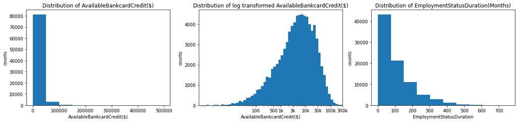

```python
plt.figure(figsize=[20,4])

plt.subplot(1,3,1) # Plot standard distribution of AvailableBankcardCredit
plt.hist(data=loanClean, x='AvailableBankcardCredit', bins=10)
plt.xlabel('AvailableBankcardCredit($)')
plt.ylabel('counts')
plt.title('Distribution of AvailableBankcardCredit($)');

plt.subplot(1,3,2) # Plot log scale transformation distribution of AvailableBankcardCredit
abins = 10**np.arange(0,6+0.1, 0.1)
plt.hist(data=loanClean, x='AvailableBankcardCredit', bins=abins)
plt.xscale('log')
ticks = [100, 500, 1000, 3000, 10000, 30000, 100000, 300000, 500000]
labels= ['100', '500', '1k', '3k', '10k', '30k', '100k', '300k', '500k']
plt.xticks(ticks,labels)
plt.xlim(xmax=300000)
plt.xlabel('AvailableBankcardCredit($)')
plt.ylabel('counts')
plt.title('Distribution of log transformed AvailableBankcardCredit($)');


plt.subplot(1,3,3) # Plot distribution of EmploymentStatusDuration
plt.hist(data=loanClean, x='EmploymentStatusDuration')
plt.xlabel('EmploymentStatusDuration')
plt.ylabel('counts')
plt.title('Distribution of EmploymentStatusDuration(Months)');
```

```python
# Compute value counts and Proportions
term_counts = loanClean.Term.value_counts()
term_counts_sum = loanClean.Term.value_counts().sum()
max_term_counts = term_counts[0:1]
term_max_prop = max_term_counts/term_counts_sum
rate_counts = loanClean.ProsperRating.value_counts()
credit_counts = loanClean.CreditScoreRange.value_counts()
list_count=loanClean["ListingCategory"].value_counts()
list_order = list_count.index
income_count=loanClean['IncomeRange'].value_counts()
income_order = income_count.index
```

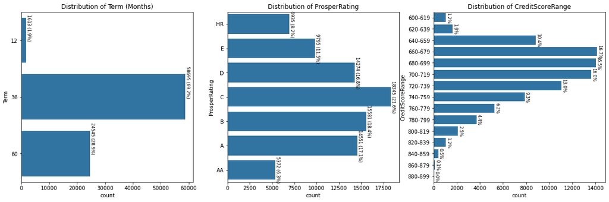

```python
# univariate plots of LoanStatus, ProsperRating, and CreditScoreRange
plt.figure(figsize=(20,6))  # size of plot
colors = sb.color_palette()[0]


plt.subplot(1,3,1) # Plot a distribution of LoanTerm
sb.countplot(data=loanClean, y='Term', color=colors)
plt.title('Distribution of Term (Months)');

locs, labels = plt.yticks() # location of ticks and labels

for loc, label in zip(locs, labels):
    termcount = term_counts[int(label.get_text())]
    pct_str = '{} ({:0.1f}%)'.format(termcount, 100*termcount/term_counts_sum)
    plt.text(y=loc, x=termcount, s=pct_str, va='baseline', rotation=270, fontsize='small')


plt.subplot(1,3,2) # Plot the distribution of ProsperRating
sb.countplot(data=loanClean, y='ProsperRating', color=colors);
plt.title('Distribution of ProsperRating');

locs, labels = plt.yticks()

for loc, label in zip(locs, labels):
    ratecount = rate_counts[label.get_text()]
    ratepct_str = '{} ({:0.1f}%)'.format(ratecount, 100*ratecount/term_counts_sum)
    plt.text(y=loc, x=ratecount, s=ratepct_str, va='center', rotation=270, fontsize='small')

plt.subplot(1,3,3) # Plot the distribution of CreditScoreRange
sb.countplot(data=loanClean, y='CreditScoreRange', color=colors);
plt.title('Distribution of CreditScoreRange');

locs, labels = plt.yticks()

for loc, label in zip(locs, labels):
    creditcount = credit_counts[label.get_text()]
    creditpct_str = '{:0.1f}%'.format(100*creditcount/term_counts_sum)
    plt.text(y=loc, x=creditcount, s=creditpct_str, va='center', rotation=270,fontsize='small')
```

**Observation**: The Prosper Loan platform offers 3 choices of Loan duration. the duration of 36 months (3 years) the most popular choice and 1 year duration is the least selected option. **ProsperRating**; shows the Rating C to be the most common rating and rating AA(the best Rating) to be the least common. **CreditScoreRange** shows a right skewed distribution having less entries at Higher Credit Ranges.

### Question: How are IncomeRange, ListingCategory, EmloymentStatus distributed?

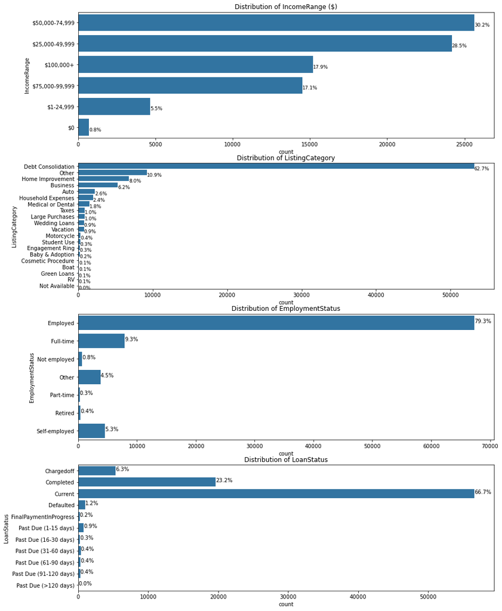

```python
plt.figure(figsize=(14,20))

plt.subplot(4,1,1)
sb.countplot(data = loanClean, y = 'IncomeRange', color=colors, order=income_order)# plot distribution of IncomeRange
plt.title('Distribution of IncomeRange ($)');

for i in range(income_count.shape[0]):
    count=income_count[i]
    pct_string='{:0.1f}%'.format(100*count/loanClean.shape[0])
    plt.text(count,i,pct_string,va="top", fontsize=9)

plt.subplot(4,1,2)
sb.countplot(data = loanClean, y = 'ListingCategory', color=colors, order=list_order)
plt.title('Distribution of ListingCategory');

for i in range(list_count.shape[0]):
    count=list_count[i]
    pct_string='{:0.1f}%'.format(100*count/loanClean.shape[0])
    plt.text(count,i,pct_string,va="top", fontsize=9) #{'center', 'top', 'bottom', 'baseline', 'center_baseline'}

plt.subplot(4,1,3)
sb.countplot(data = loanClean, y = 'EmploymentStatus', color=colors)
plt.title('Distribution of EmploymentStatus');

column_count=loanClean["EmploymentStatus"].value_counts()
locs,labels=plt.yticks()
for loc,label in zip(locs,labels):
    count=column_count[label.get_text()]
    pct_string= "{:0.1f}%".format(100*count/loanClean.shape[0])
    plt.text(y=loc, x=count, s=pct_string,ha="left",fontsize='medium')

plt.subplot(4,1,4)
sb.countplot(data = loanClean, y = 'LoanStatus', color=colors)
plt.title('Distribution of LoanStatus');

loan_count=loanClean["LoanStatus"].value_counts()
locs,labels=plt.yticks()
for loc,label in zip(locs,labels):
    count=loan_count[label.get_text()]
    pct_string= "{:0.1f}%".format(100*count/loanClean.shape[0])
    plt.text(y=loc, x=count, s=pct_string,ha="left",fontsize='medium')
```

**Observation**: From the above charts we can see that the most commonn **IncomeRange** is the median income range of 50,000USD - 74,000USD, with majority of Listings earning from somewhere around 25,000USD and above. The most common **ListingCategory** is Debt Consolidation. with 80% of loans having an **EmploymentStatus** of Employed. **LoanStatus** 66.7% of Loans are in the Current status, followed closely by completed loans at 23.2%. there is a signifant proportion of Chargedoff and Defaulted Loans, at 6.3% and 1.2% respectively.

**Additional wrangling**: Categorise StatedMonthlyIncome Variable, inorder to get of how high or low an income is. (just incase i might need it)

```python
def income_Cat(row):
    if row["StatedMonthlyIncome"]<2500:
        return 'Low'
    if row["StatedMonthlyIncome"]<8000:
        return 'Medium'
    else:
        return 'High'

loanClean['WageStage'] = loanClean.apply(income_Cat, axis=1)

# convert string to ordinal category type
wage_cat = ['Low', 'Medium', 'High']
ord_wage = pd.api.types.CategoricalDtype(ordered = True, categories = wage_cat)
loanClean['WageStage'] = loanClean['WageStage'].astype(ord_wage)
```

### Of the features you investigated, were there any unusual distributions? Did you perform any operations on the data to tidy, adjust, or change the form of the data? If so, why did you do this?

> The distribution of the DebtToIncomeRatio was highly skewed by the presence of those with very high incomes to their debt. This isn't unexpected in a real-world scenario and does not need transformations implemented on data. just I limit x-axis to focus on distribution

## Bivariate Exploration

In this section, I will be invesgitating Pairs of variables in the dataset which have been previously introduced through Univariate exploration. The goal is observe interactions and possibly uncover relationsships between variables.

```python
# Create sample dataframe for smoother smoother rendering
samples = np.random.choice(loanClean.shape[0], 2500, replace = False)
loanClean_samp = loanClean.loc[samples]
```

### Question: How does BorrowerAPR interact with Qualitative variables

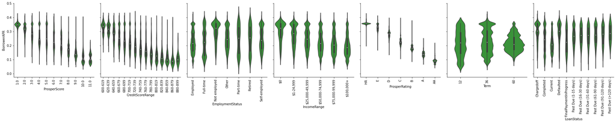

```python
#define violin function
def violin(x, y, **kwargs):
    default_color = sb.color_palette()[2]
    sb.violinplot(x, y, color = default_color)
    plt.xticks(rotation=90);

g = sb.PairGrid(data = loanClean, y_vars = ['BorrowerAPR'],
                x_vars = ['ProsperScore','CreditScoreRange','EmploymentStatus','IncomeRange', 'ProsperRating', 'Term', 'LoanStatus'], size = 4)
g.map(violin)
plt.show();
```

**Observation**:

> **ProsperScore/ProsperRating** shows a negatie interaction with BorrowerAPR, as ProsperScores rise Borrower APR decreases. But we can also notice an undulating trend at ProsperScores 4 and 5, BorrowerAPR follows a decreasing trend up until ProsperScore of 4 then BorrowerAPR increases as ProsperScore increases from 4 to 5. this could be due to some qualitative factors like Employment Status or LoanStatus.

> **CreditScoreRange** generally shows an inverse relationship with BorrowerAPR, Higher CreditScoreRange suggests lower BorrowerAPR, up until the last(Highest) CreditScoreRange where we see the avergae BorrowerAPR begin to reverse the trend

> **EmploymentStatus** does not show any particular trend, it does shows Employed, Fulltiime, other and Self Employed Borrowers gain more favourable BorrowerAPR compared to NotEmployed, Retired and Part-time workers. we can look further into this

> **IncomeRange and ProsperRating** show negative interaction with BorrowerAPR, Higher ranges of Income and ProsperRating suggests Lower values of BorrowerAPR. making IncomeRange, ProsperRating very good predictors of BorrowerAPR.

> **BorrowerAPR vs LoanStatus** Chargedoff loans corresponds with High BorrowerAPRs, Completed LoanStatus corresponds with even lower BorrowerAPRs compared to Prior LoanStatus. Defaulted loanstatus corresponds with High BorrowerAPRs similar to Chargedoff loans. FinalPaymentinprogress have low BorrowerAPRs similar to currentloanStatus, we can explore this further with the ProsperRating.

### Question: How does BorrowerAPR interact with Quantitative variables?

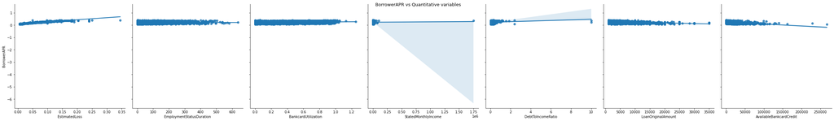

```python
g = sb.PairGrid(data = loanClean_samp, y_vars = ['BorrowerAPR'],
                x_vars = ['EstimatedLoss','EmploymentStatusDuration','BankcardUtilization','StatedMonthlyIncome', 'DebtToIncomeRatio', 'LoanOriginalAmount', 'AvailableBankcardCredit'], size = 5)
g.map(sb.regplot)
plt.suptitle('BorrowerAPR vs Quantitative variables', fontsize=13)

plt.show();
```

**Observation**:

> **EstimatedLoss** shows a very postive interaction with BorrowerAPR, Higher values of Estimated Loss corresponds with Higher values of BorrowerAPR as Borrowers estimated to generate poor yeild are Charged Higher APR to discourage demand for loan and protect investors.

> **DebttoIncomeratio** shows that increased levels of DebttoIncomeRatio attracts Higher BorrowerAPR, DebttoincomeRatio seems to be a good explanatory variable of interest.

> **LoanOriginalAmount** we observed that at the different sizes of the total loan amount, the borrower's APR has a large distribution, but the range of APR decreases with the increase of loan amount. So the borrower's APR is negatively correlated with the total loan amount.Although this correlation is weak, we can introduce an extra variable of interest (ProsperRating) into the mix to observe any interesting dynamics as LoanOriginalAmount has been observed to have a positive correlation to ProsperRating.

> **AvailableBankcardCredit** shows a negative interaction with BorrowerAPR with higher AvailableBankcardCredit values corresponding with lower BorroweAPR values.

### Question: How does ProsperScore relate to categorical variables?

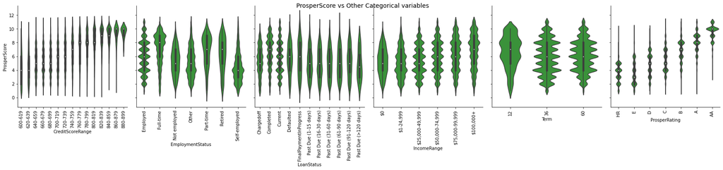

```python
g = sb.PairGrid(data = loanClean, y_vars = ['ProsperScore'], x_vars = ['CreditScoreRange','EmploymentStatus','LoanStatus', 'IncomeRange', 'Term', 'ProsperRating'], size = 4)
g.map(violin)
plt.suptitle('ProsperScore vs Other Categorical variables', fontsize=14)
plt.show();
```

**Question**:

> **CreditScoreGrade** has a positive interaction with ProsperScore, ProsperScore rises with a corresponding rise in the median counts of CreditScoreRange. with the last two CreditScoreRanges(860-879, 880-899) having an average ProsperScore of 10.

> **EmploymentStatus** shows that Part time employees have the highest range of values corresponding with very high ProsperScores. This might be due to Part-time employees taking lower loan amounts which are easier to pay off.

> **Term** shows 12months LoanTerm avergage acquire higher ProsperScore(i.e Better Risk score), this could be to encourage borrowers to take smaller loans in shorter time frames which have a higher probability of being paid off. this can be explored further

### Question: How does Prosper Risk Score interact with Quantitative variable?

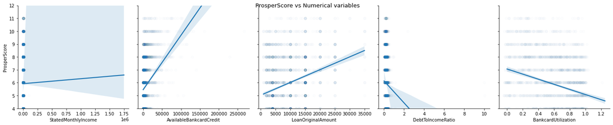

```python
g = sb.PairGrid(data = loanClean_samp, y_vars = ['ProsperScore'],
                x_vars = ['StatedMonthlyIncome', 'AvailableBankcardCredit', 'LoanOriginalAmount', 'DebtToIncomeRatio', 'BankcardUtilization'], size = 4)
g.map(sb.regplot, scatter_kws={'alpha': 0.01}, x_jitter=0.04 )
plt.ylim(bottom=4, top=12)
plt.suptitle('ProsperScore vs Numerical variables', fontsize=13)
plt.show();
```

**Observation**

> **StatedMonthlyIncome** shows that majority of listings state a monthly income between 0 and 10000USD. it also shows that as statedmonthly income increases, ProsperScore increases but statedmonthly income increases much more rapidly than ProsperScore increases. **AvailbleBankcardCredit** also increases with as prosperscore increases, indicating that higher AvailableBankcardCredit might have a positive interaction with ProsperScore. therefore Borrowers with high availablebankcardcredit are likely to receive high ProsperScores.

> **Debttoincomeratio** shows that lower ratios correlates with higher ProsperScores, which makes a reliable indicator for credit worthiness.

> **BankcardUtilization** indicates that a negative relationship. low BankcardUtilisation percentage corresponds with Higer ProsperScore(Low Risk)

### Question: How does LoanOriginalAmount relate to StatedMonthlyIncome, AvailableBankcardCredit, DebtToIncomeRatio?

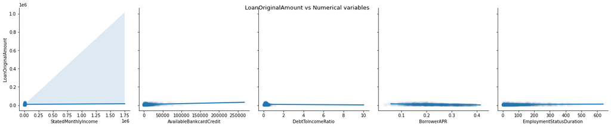

```python
g = sb.PairGrid(data = loanClean_samp, y_vars = ['LoanOriginalAmount'],
                x_vars = ['StatedMonthlyIncome', 'AvailableBankcardCredit', 'DebtToIncomeRatio', 'BorrowerAPR', 'EmploymentStatusDuration'], size = 4)
g.map(sb.regplot, scatter_kws={'alpha': 0.01}, x_jitter=0.04)
plt.suptitle('LoanOriginalAmount vs Numerical variables', fontsize=13)
plt.show();
```

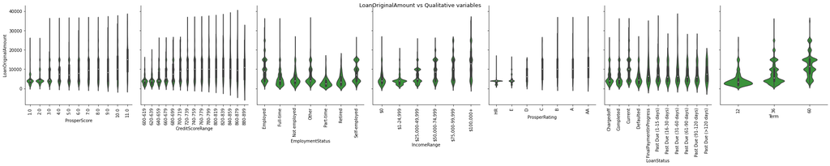

```python
g = sb.PairGrid(data = loanClean, y_vars = ['LoanOriginalAmount'],
                x_vars = ['ProsperScore','CreditScoreRange','EmploymentStatus','IncomeRange', 'ProsperRating', 'LoanStatus', 'Term'], size = 4)
g.map(violin)
plt.suptitle('LoanOriginalAmount vs Qualitative variables', fontsize=13)
plt.show();
```

**Observation**:

> **AvailableBankcardCredit** shows that more Borrowers with High AvailableBankcardCredit corresponds with High Loan Amounts, although this correlation is weak, it does suggest that AvailableBankcardCredit and LoanOriginalAmount do not improve at the same pace and consistency, indicating the AvailableBankcardCredit might not be a good predictor of LoanOriginalAmount.

> **DebttoIncomeRatio**: The downward slope between Debttoincomeratio and Original loan amount suggests that an Increase in Debttoincomeratio relatively correlates with lesser loan amount, indicating that more borrowers with a High Debttoincomeratio are inclined to borrow less. This might imply that borrowers having a hard time servicing their debt are more likely to borrower lesser loan amouunts.

> **CreditScoreRange**: shows an upward positive interaction with LoanOriginalAmounts, Loanamounts increase with improvements in CreditScoreRanges.

> **Term**: shows a positive interaction with LoanOriginalAmounts, Longer Loan Duration tend to attract Larger LoanOriginalAmounts.

> **EmploymentStatus**: shows no trend, but it is we can observe that Employed and Self-Employed Borrowers had higher LoanAmounts on average compared to any other EmploymentStatus.

### Question: How does Numerical variables correlate with one another?

```python
# Group variables into numerical and categorical data for visualisation purposes
num_variables = ['BorrowerAPR', 'ProsperScore', 'EmploymentStatusDuration', 'BankcardUtilization', 'AvailableBankcardCredit', 'DebtToIncomeRatio', 'LoanOriginalAmount', 'StatedMonthlyIncome', 'Term']
cat_variables = ['Term', 'LoanStatus', 'ProsperRating', 'ListingCategory', 'EmploymentStatus', 'IncomeRange', 'CreditScoreRange']
num_varss = ['BorrowerAPR', 'ProsperScore', 'EmploymentStatusDuration', 'Term', 'AvailableBankcardCredit', 'DebtToIncomeRatio']
cat_varss = ['LoanStatus', 'ProsperRating', 'ListingCategory', 'EmploymentStatus', 'IncomeRange', 'CreditScoreRange']
```

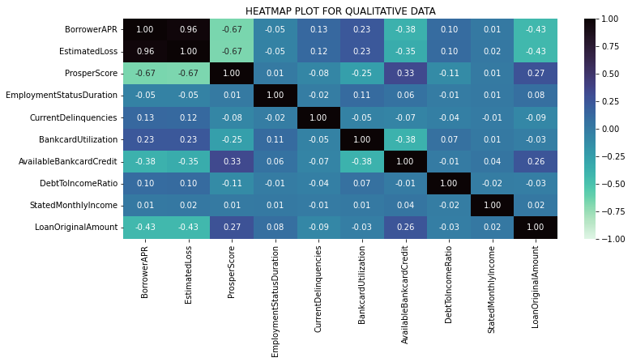

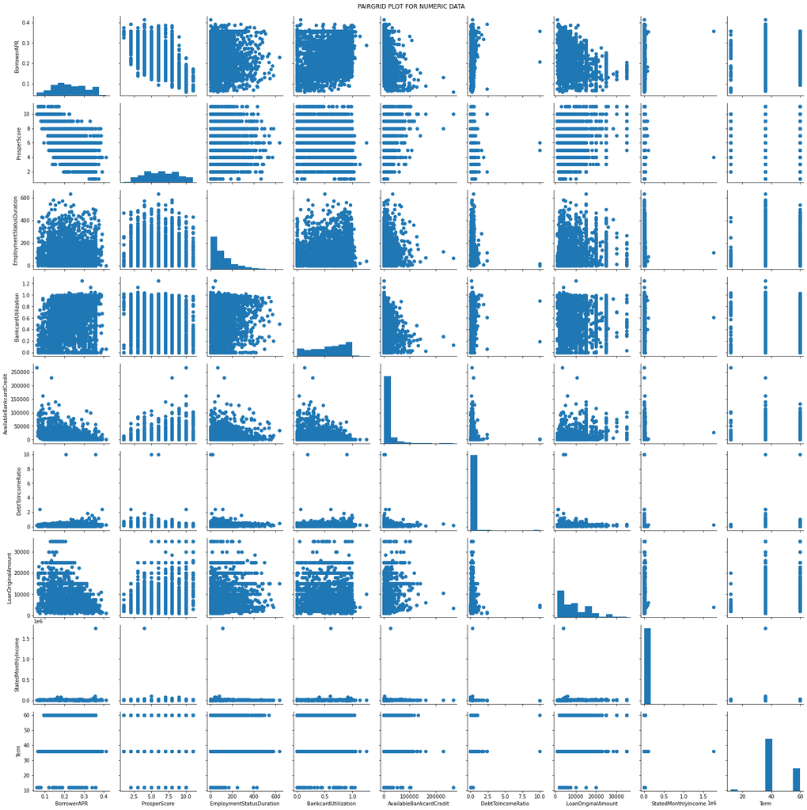

```python
# plot matrix: sample 500 diamonds so that plots are clearer and
# they render faster

plt.figure(figsize=(12,5))
sb.heatmap(loanClean_samp.corr(), cmap='mako_r', annot=True, fmt='.2f', vmin=-1, vmax=1);
plt.title('HEATMAP PLOT FOR QUALITATIVE DATA');

g = sb.PairGrid(data=loanClean_samp, vars=num_variables)
g = g.map_offdiag(plt.scatter)
g.map_diag(plt.hist)
plt.suptitle('PAIRGRID PLOT FOR NUMERIC DATA', y=(1));
```

**Observation**:

### Question: How do Other Numeric variables interact with Qualitative Variables?

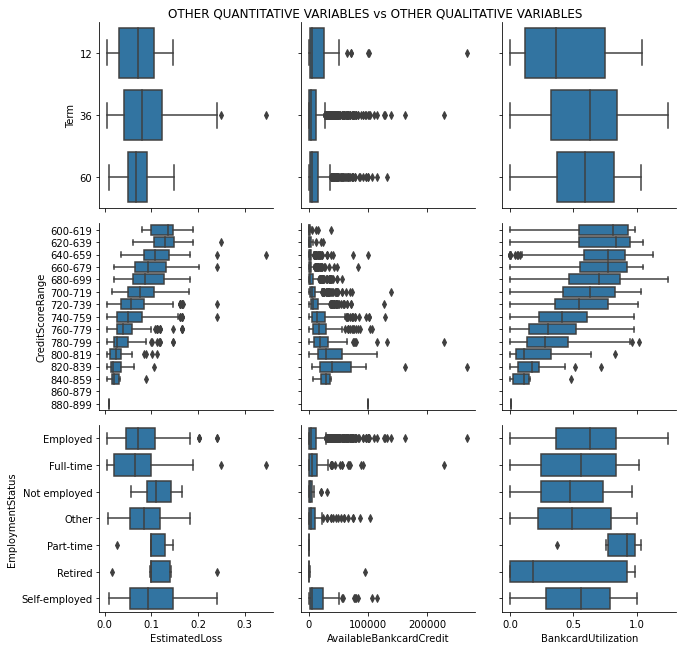

```python
# define function to generate boxplots with PairGrid
def boxgrid(x, y, **kwargs):
    """ Quick hack for creating box plots with seaborn's PairGrid. """
    default_color = sb.color_palette()[0]
    sb.boxplot(x, y, color = default_color)

plt.figure(figsize = [12, 8])
g = sb.PairGrid(data = loanClean_samp, x_vars = ['EstimatedLoss', 'AvailableBankcardCredit', 'BankcardUtilization'], y_vars= ['Term', 'CreditScoreRange', 'EmploymentStatus'],
                size = 3)
g.map(boxgrid)
plt.suptitle('OTHER QUANTITATIVE VARIABLES vs OTHER QUALITATIVE VARIABLES', y=(1))
plt.show();
```

**Observation**:

> AvailableBankcardCredit shows a relatively neutral relationship with LoanTerms, suggesting that the available credit balances might not indicate a borrowers Term of preference. On the other hand, its interaction with CreditScoreRange shows a positive trend, suggesting that borrowers with more AvailableBankcardCredit are likely to fall into Higher CreditScoreRange.

> BankcardUtilization shows a no correlation with Loan Term, on the other hand it shows a negative trend in its interaction with CreditScoreRange, the Highest credit score ranges shows a median Bankcardutilization of 0.1, indicating that lower Bankcardutilization is a suitable metric for credit suitability.

### Question: How do Categorical variables interact with one another?

```python
# Create Sample plots for simple visualisation of the most relevant LoanStatus
loanstatus = ['Chargedoff', 'Completed', 'Current', 'Defaulted', 'FinalPaymentInProgress', 'Past Due (1-15 days)']
loanstatus_DF = loanClean[loanClean['LoanStatus'].isin(loanstatus)]
loanstatus_DF.reset_index(drop=True, inplace=True)
loanstatus_DF['LoanStatus'] = loanstatus_DF['LoanStatus'].astype('object')
print(loanstatus_DF.LoanStatus.unique())
print(loanstatus_DF.shape)


sampless = np.random.choice(loanstatus_DF.shape[0], 1500, replace = False)
loanstatus_DFsamp = loanstatus_DF.loc[sampless]
loanstatus_DFsamp.reset_index(drop=True, inplace=True)
print(loanstatus_DFsamp.shape)
```

```
['Current' 'Past Due (1-15 days)' 'Defaulted' 'Completed' 'Chargedoff'
 'FinalPaymentInProgress']
(83592, 20)
(1500, 20)
```

```python
# Create dataframe containing value proportions
df1 = loanstatus_DF.groupby(['EmploymentStatus', 'LoanStatus'])['LoanStatus'].count()
df2 = df1.groupby(level=0).apply(lambda x: 100 * x/x.sum()).reset_index(name='Proportion')

df3 = loanClean.groupby(['LoanStatus', 'CreditScoreRange'])['CreditScoreRange'].count()
df4 = df3.groupby(level=0).apply(lambda x: 100 * x/x.sum()).reset_index(name='Proportion')
```

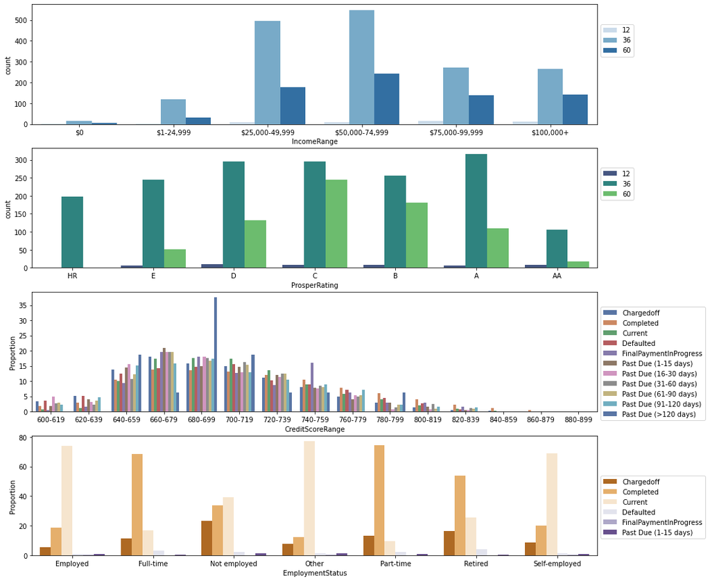

```python
# Create Bivariate plots of Categorical variables; IncomeRange, Term, CreditScoreRange, ProsperRating
plt.figure(figsize = [15, 15])

# subplot 1: IncomeRange vs Term
plt.subplot(4, 1, 1)
sb.countplot(data = loanClean_samp, x = 'IncomeRange', hue = 'Term', palette = 'Blues')
plt.legend(loc=6, bbox_to_anchor=(1.0,0.7));

# subplot 2: ProsperRating vs Term
ax = plt.subplot(4, 1, 2)
sb.countplot(data = loanClean_samp, x = 'ProsperRating', hue = 'Term', palette = 'viridis')
ax = plt.legend(loc=6, bbox_to_anchor=(1.0,0.7)); # re-arrange legend to reduce overlapping

# subplot 3: EmploymentStatus vs CreditScoreRange
ax = plt.subplot(4, 1, 3)
sb.barplot(data = df4, hue= 'LoanStatus', x= 'CreditScoreRange',y='Proportion', palette = 'deep')
ax = plt.legend(loc=6, bbox_to_anchor=(1.0,0.4));

ax = plt.subplot(4, 1, 4) # EmploymentStatus vs LoanStatus
sb.barplot(data=df2, x= 'EmploymentStatus', y= 'Proportion', hue='LoanStatus', palette='PuOr')
ax = plt.legend(loc=6, bbox_to_anchor=(1.0,0.4));

plt.show()
```

**Observation**:

> Income Range vs Term shows a unimodal distribution, across all income ranges, loan term of 12 months are scarce. loan Terms of 36months are more prevalent followed by 60 months loan Term. IncomeRanges of 25000USD-49999USD to 50000USD-74999USD contain more 36month loan term than other ranges.

> ProsperRating vs Term, accross all ratings 36 months loan term are the most prevalent.

## Multivariate Exploration

I will be investigating further into rising BorrowerAPR despite the improvement in CreditScoreRange

### Question: Investigation into the rise in BorroweAPR in relation to CreditScoreRange, LoanOriginalAmount and LoanStatus.

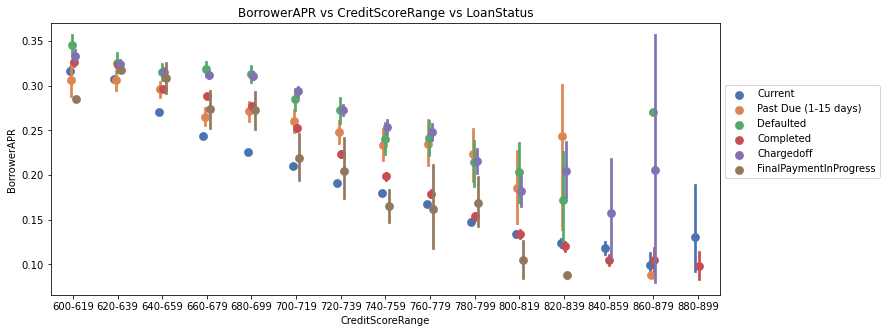

```python
# Plot the levels of LoanStatus across EmploymentStatus and observe it's effect on BorrowerAPR.
# I will only be working with the most importatant LoanStatuss i.e(Chargedoff, Completed, Current, Defaulted, FinalPaymentsinProgress, PastDue(1-15 days))
plt.figure(figsize=[12,5])
sb.pointplot(data=loanstatus_DF, y='BorrowerAPR', x='CreditScoreRange', hue='LoanStatus', dodge=True, linestyles='', palette='deep')
plt.title('BorrowerAPR vs CreditScoreRange vs LoanStatus')
plt.legend(loc=6, bbox_to_anchor=(1.0,0.6));
```

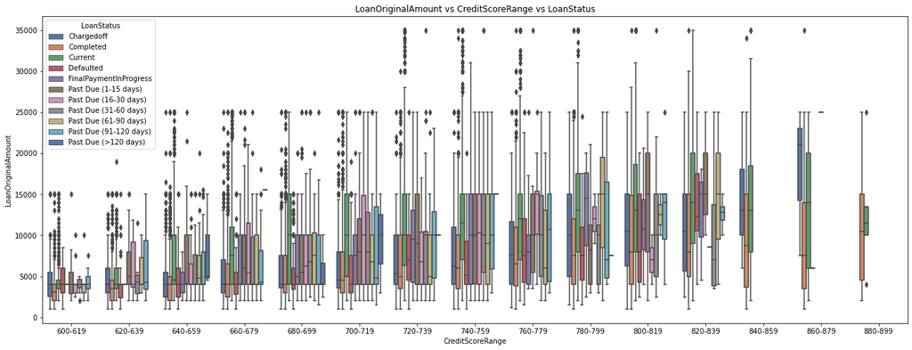

```python
plt.figure(figsize=[22,8])
sb.boxplot(data=loanClean,x='CreditScoreRange',y='LoanOriginalAmount',hue='LoanStatus', palette='deep')
plt.title('LoanOriginalAmount vs CreditScoreRange vs LoanStatus');
```

```python
# Create dataframe of high CreditScoreGrade
highcreditscorerange_loanStatus_loanamounts = loanstatus_DF.loc[loanstatus_DF['CreditScoreRange'].isin(['800-819', '820-839', '840-859', '860-879', '880-899'])]
highcreditgrade_sub_DF = highcreditscorerange_loanStatus_loanamounts[['CreditScoreRange', 'LoanOriginalAmount', 'LoanStatus', 'BorrowerAPR']].sort_values(by=['CreditScoreRange','BorrowerAPR'], ascending=False)
highcreditgrade_sub_DF['CreditScoreRange'] = highcreditgrade_sub_DF['CreditScoreRange'].astype('object')
highcreditgrade_sub_DF['CreditScoreRange'] = highcreditgrade_sub_DF['CreditScoreRange'].astype('object')

creditrange = highcreditgrade_sub_DF['CreditScoreRange'].unique().tolist().sort()
creditgrade = pd.api.types.CategoricalDtype(ordered=True, categories=creditrange)
highcreditgrade_sub_DF['CreditScoreRange'] = highcreditgrade_sub_DF['CreditScoreRange'].astype(creditgrade)
# Test:
highcreditgrade_sub_DF.CreditScoreRange.dtypes
```

```
CategoricalDtype(categories=['800-819', '820-839', '840-859', '860-879', '880-899'], ordered=True)
```

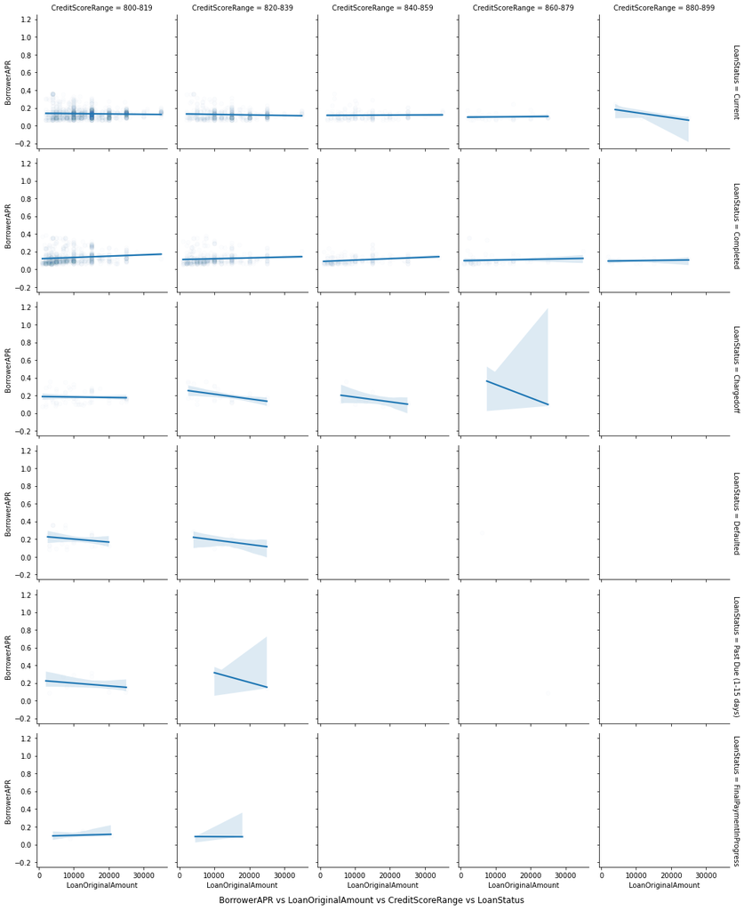

```python
g = sb.FacetGrid(data = highcreditgrade_sub_DF, col= 'CreditScoreRange', size = 3, margin_titles = True, row='LoanStatus')
g.map(sb.regplot, 'LoanOriginalAmount', 'BorrowerAPR', scatter_kws={'alpha': 0.01}, x_jitter=0.04)
plt.suptitle('BorrowerAPR vs LoanOriginalAmount vs CreditScoreRange vs LoanStatus', y=0)
plt.show();
```

**Observation**:

### Question: How does LoanStatus affect BorrowerAPR accorss Borrowers from all works of life?

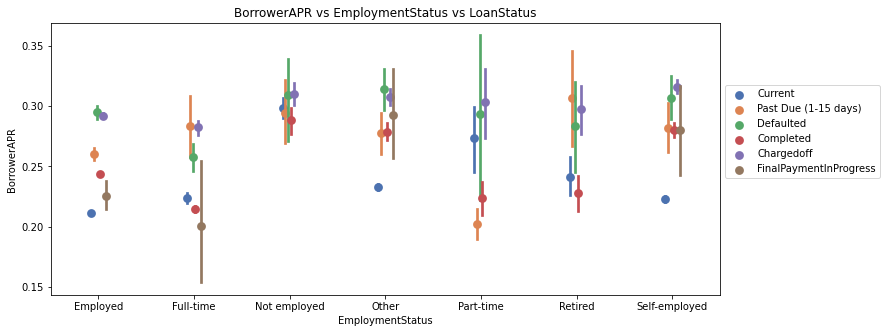

```python
plt.figure(figsize=[12,5])
sb.pointplot(data=loanstatus_DF, y='BorrowerAPR', hue='LoanStatus', x='EmploymentStatus', dodge=True, linestyles='', palette='deep')
plt.legend(loc=6, bbox_to_anchor=(1.0,0.6))
plt.title('BorrowerAPR vs EmploymentStatus vs LoanStatus', y=1);
```

**Observation**:

### Question: Let's investigate CreditScoreRange and BorrowerAPR by Introducing LoanOriginalAmount

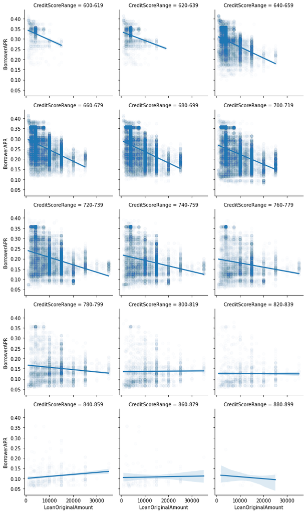

```python
g = sb.FacetGrid(data = loanClean, col= 'CreditScoreRange', size = 3, margin_titles = True, col_wrap=3)
g.map(sb.regplot, 'LoanOriginalAmount', 'BorrowerAPR', scatter_kws={'alpha': 0.01}, x_jitter=0.04)
plt.show()
```

**Observation**:

- At the first Nine stages of CreditScoreGrade, Borrowers enjoy a negative relationship between BorrowerAPR and LoanOriginalAmount, at the CreditScoreRanges of (780-799) onward, we begin to see weak correlation and eventually no correlation between BorrowerAPR and LoanOriginalAmount as higher Loanamounts no Longer attract lower BorrowerAPR. At CreditScoreRange (840-859) onward, we even begin to see that higher loan amounts now required Higher BorrowerAPR possibly due lenders not wanting to charge BorrowerAPR lower than 10% for profitability reasons, as Borrowers in these CreditScoreRanges might be inclined to borrower even larger amounts considering the low rates for LongerTerms, which have a higher probability of going defunct. at (880) we then begin to a further dip in BorrowerAPR, possibly due to very low loan amounts being demanded due to prior increase in BorrowerAPR corresponding with Large Loan amounts.

### Talk about some of the relationships you observed in this part of the investigation. Were there features that strengthened each other in terms of looking at your feature(s) of interest?

> BorrowerAPR showed a negative relationship to CreditScoreRange up unitl the last range (880-899) where BorrowerAPR showed an inerse relationship to CreditScoreRange.

### Were there any interesting or surprising interactions between features?

> LoanOriginalAmounts vs CreditScoreRange vs LoanStatus: At most CreditScoreRanges, current loans had the Higher avergage LoanOriginalAmounts, with the exception of (600-619), (620-639) and (800-899). In the case of CreditScoreRange (880-899), we that there is a decline in the average loan amounts at the Current LoanStatus when compared to the previous CreditScoreRange. this is in opposition to the increasing Loan Amounts of Current Loans as CreditScoreRange improves.

## Conclusions

From our Bivarite exploration of BorrowerAPR vs CreditScoreRange, we observe a negative correlation as stated above, up untill the Highest CreditScoreRange were we begin to notice a rise in average BorrowerAPR, which is in contrast to the prior trend of average BorrowerAPR declining, following an improvement in CreditScoreRange. Upon further exploration, we observed that at CreditScoreRange (880-899), the average loan amounts of Completed Loans incresed warranting lower BorrowerAPR, but the average LoanOriginalAmounts of Current Loans declined greatly, which might warrant higher BorrowerAPR.

### Limitations:

> The heavy Presence of missing data could lead to uncertainty in our analysis and conclusions.

### References:

file:///C:/Users/Userr/Desktop/DATA%20ANA%20Pt%203/Example%20Project/Example_Project_Diamonds_Part1.html, https://rpubs.com/jayant_singh/Prosper-Loan, https://www.kaggle.com/code/abanoubyoussef/prosper-loan-data-exploration, https://github.com/0xjimm/prosper-loan-data-findings/blob/master/prosper-loan-data-exploration.ipynb, https://stackoverflow.com/questions/19913659/pandas-conditional-creation-of-a-series-dataframe-column, https://sparkbyexamples.com/pandas/pandas-dataframe-query-examples/